# R qPCR Tutorial

## Plot the Data

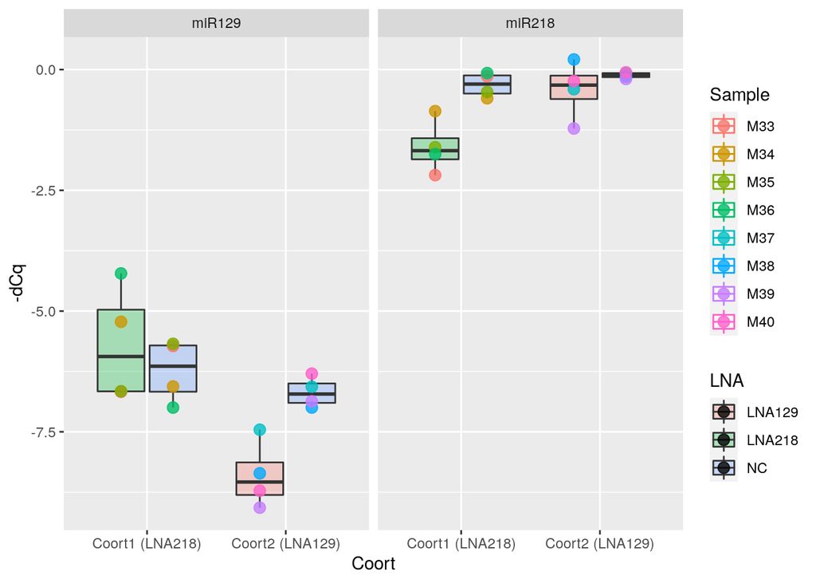

```r
p <- ggplot(data, aes(x=Coort, y=-dCq, color=Sample, fill=LNA, group= interaction(LNA, Coort)))  +
  geom_boxplot(alpha=0.3, aes(fill=LNA))+

  geom_point(aes(color=Sample), alpha=0.8, position = position_dodge(0.75), size=3) + facet_grid(. ~ Target.tar, scales="free")

p
```

### Exercise for the fast ones

1. Create a different plot where we have the microRNA on the x-axis and the two plots are split according to Coort-factor. - Which of the two kind of plots make more sense?
2. Create a plot with the fold-changes in the y-axis using your preferred arrangement in the x-axis. - Tipp: use facet_wrap instead of facet_grid. Can you find out why?

#Statistics

In this section, we are going to perform some statistical analysis. There are many ways of doing this and there will be a more in-depth seminar on just ANOVAs and linear mixed models.

## ANOVA Assumptions

First we need to consider which test we want to use. For this, we need to make sure, we are meeting the ANOVA-assumptions.

We have one factor for which we want to test the effect: Does a specific LNA inhibit the measured microRNA? This means, we are considering a one-way ANOVA.

The assumptions for an ANOVA are: 1. Experimental errors (residuals) are normally distributed (-> data does not necessarily need to be normally distributed) 2. Equal variances between treatments (sphericity assumption) 3. Independence of samples

The first two assumptions we can test visually (QQ-Plots) and with corresponding tests (Shapiro-Wilk normality test). The third assumption is based on your experimental design. In most of our cases in the lab, we don’t meet this assumption, since primary cultures are dependent from each other (genetically identical cells). Or in our case, we have repeated measurements within a mouse (hemisphere and levels of miR218/miR129). These factors are dependent from each other. We will take into account dependency into the model by including the mouse-ID into the model.

### Normality Test

We will test normality with the Shapirp-Wilk test. The null-hypothesis is that the data is normally distributed. A p-value < 0.05 means, we reject the null-hypothesis -> the data is most likely not normally distributed.

```r
## Lets perform some descriptive statistics (number of samples per group, mean and standard deviation)

data %>%
  ## here we split our data by group. You will need to change this bit to your experimental setup
  group_by(LNA, Target.tar, Coort) %>%

  ## check with help(get_summary_stats) for more extensive options of summaries
  get_summary_stats(c(dCq, Fold.dCq), type = "common")
```

```
## # A tibble: 16 × 13
##    Target.tar LNA    Coort  variable     n    min   max median   iqr  mean    sd
##    <chr>      <chr>  <chr>  <chr>    <dbl>  <dbl> <dbl>  <dbl> <dbl> <dbl> <dbl>
##  1 miR129     LNA129 Coort… dCq          4  7.46  9.07   8.54  0.674 8.40  0.694
##  2 miR129     LNA129 Coort… Fold.dCq     4  0.002 0.006  0.003 0.001 0.003 0.002
##  3 miR218     LNA129 Coort… dCq          4 -0.209 1.22   0.322 0.485 0.414 0.597
##  4 miR218     LNA129 Coort… Fold.dCq     4  0.429 1.16   0.801 0.252 0.797 0.299
##  5 miR129     LNA218 Coort… dCq          4  4.22  6.67   5.94  1.69  5.69  1.20
##  6 miR129     LNA218 Coort… Fold.dCq     4  0.01  0.054  0.018 0.024 0.025 0.021
##  7 miR218     LNA218 Coort… dCq          4  0.86  2.18   1.68  0.437 1.60  0.552
##  8 miR218     LNA218 Coort… Fold.dCq     4  0.22  0.551  0.313 0.106 0.349 0.142
##  9 miR129     NC     Coort… dCq          4  5.68  7.00   6.14  0.958 6.24  0.648
## 10 miR129     NC     Coort… Fold.dCq     4  0.008 0.02   0.015 0.009 0.014 0.006
## 11 miR129     NC     Coort… dCq          4  6.30  7.00   6.72  0.402 6.68  0.315
## 12 miR129     NC     Coort… Fold.dCq     4  0.008 0.013  0.01  0.003 0.01  0.002
## 13 miR218     NC     Coort… dCq          4  0.073 0.595  0.301 0.375 0.318 0.252
## 14 miR218     NC     Coort… Fold.dCq     4  0.662 0.95   0.817 0.21  0.812 0.14
## 15 miR218     NC     Coort… dCq          4  0.057 0.195  0.112 0.084 0.119 0.063
## 16 miR218     NC     Coort… Fold.dCq     4  0.874 0.961  0.926 0.054 0.922 0.04
## # … with 2 more variables: se <dbl>, ci <dbl>
```

```r
## Here we perform the Shapiro-Wilk normality test by splitting the data in groups
data %>%
  group_by(LNA, Target.tar, Coort) %>%
  shapiro_test(dCq) %>%
 add_significance("p")
```

```
## # A tibble: 8 × 7
##   Target.tar LNA    Coort           variable statistic     p p.signif
##   <chr>      <chr>  <chr>           <chr>        <dbl> <dbl> <chr>
## 1 miR129     LNA129 Coort2 (LNA129) dCq          0.947 0.699 ns
## 2 miR218     LNA129 Coort2 (LNA129) dCq          0.955 0.746 ns
## 3 miR129     LNA218 Coort1 (LNA218) dCq          0.864 0.276 ns
## 4 miR218     LNA218 Coort1 (LNA218) dCq          0.957 0.757 ns
## 5 miR129     NC     Coort1 (LNA218) dCq          0.869 0.294 ns
## 6 miR129     NC     Coort2 (LNA129) dCq          0.955 0.748 ns
## 7 miR218     NC     Coort1 (LNA218) dCq          0.895 0.406 ns
## 8 miR218     NC     Coort2 (LNA129) dCq          0.942 0.664 ns
```

```r
## Here we perform the Shapiro-Wilk normality test by splitting the data in groups
data %>%
  group_by(LNA, Target.tar, Coort) %>%
  ##Lets take the fold changes here instead of dCq
  shapiro_test(Fold.dCq) %>%
 add_significance("p")
```

```
## # A tibble: 8 × 7
##   Target.tar LNA    Coort           variable statistic     p p.signif
##   <chr>      <chr>  <chr>           <chr>        <dbl> <dbl> <chr>
## 1 miR129     LNA129 Coort2 (LNA129) Fold.dCq     0.866 0.282 ns
## 2 miR218     LNA129 Coort2 (LNA129) Fold.dCq     0.988 0.947 ns
## 3 miR129     LNA218 Coort1 (LNA218) Fold.dCq     0.846 0.213 ns
## 4 miR218     LNA218 Coort1 (LNA218) Fold.dCq     0.894 0.400 ns
## 5 miR129     NC     Coort1 (LNA218) Fold.dCq     0.852 0.233 ns
## 6 miR129     NC     Coort2 (LNA129) Fold.dCq     0.943 0.670 ns
## 7 miR218     NC     Coort1 (LNA218) Fold.dCq     0.893 0.396 ns
## 8 miR218     NC     Coort2 (LNA129) Fold.dCq     0.943 0.671 ns
```

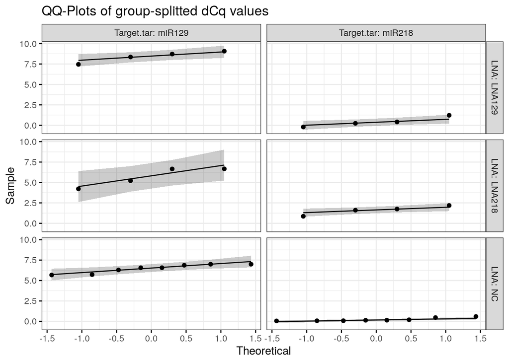

```r
ggqqplot(data, "dCq", ggtheme = theme_bw()) +
  facet_grid(LNA ~ Target.tar, labeller = "label_both") + labs(title="QQ-Plots of group-splitted dCq values")
```

```r
## A QQ-plot probably does not make a lot of sense with n=4 per group. However, it still follows the expected trendline quite nicely.
```

## ANOVA Statistics

Technically, we are not allowed to use a classical ANOVA to model our data, since our experimental design does not meet the 3rd requirement. For educational purposes, we will implement both analyses. If we put together in the same model LNA effects and gene effect, then we are performing a two-way ANOVA. Since we are using a multiplicative model (denoted by the * sign instead of a + sign) we can check for interaction-effects between LNA and gene-expression. This will also allow us later to perform contrasts on all levels.

## Classical ANOVA

```r
## This command performs the ANOVA analysis and stores it in the variable mod (you can name it as you want ofc)
mod <- aov(-dCq ~ LNA*Target.tar, data)
summary(mod)
```

```
##                Df Sum Sq Mean Sq F value  Pr(>F)
## LNA             2   6.10    3.05   7.974 0.00199 **
## Target.tar      1 301.75  301.75 789.327 < 2e-16 ***
## LNA:Target.tar  2  15.26    7.63  19.953 5.6e-06 ***
## Residuals      26   9.94    0.38
## ---
## Signif. codes:  0 '***' 0.001 '**' 0.01 '*' 0.05 '.' 0.1 ' ' 1
```

```r
#lets test the normality of the residuals of our model

shapiro.test(residuals(mod))
```

```
##
##  Shapiro-Wilk normality test
##
## data:  residuals(mod)
## W = 0.96954, p-value = 0.4868
```

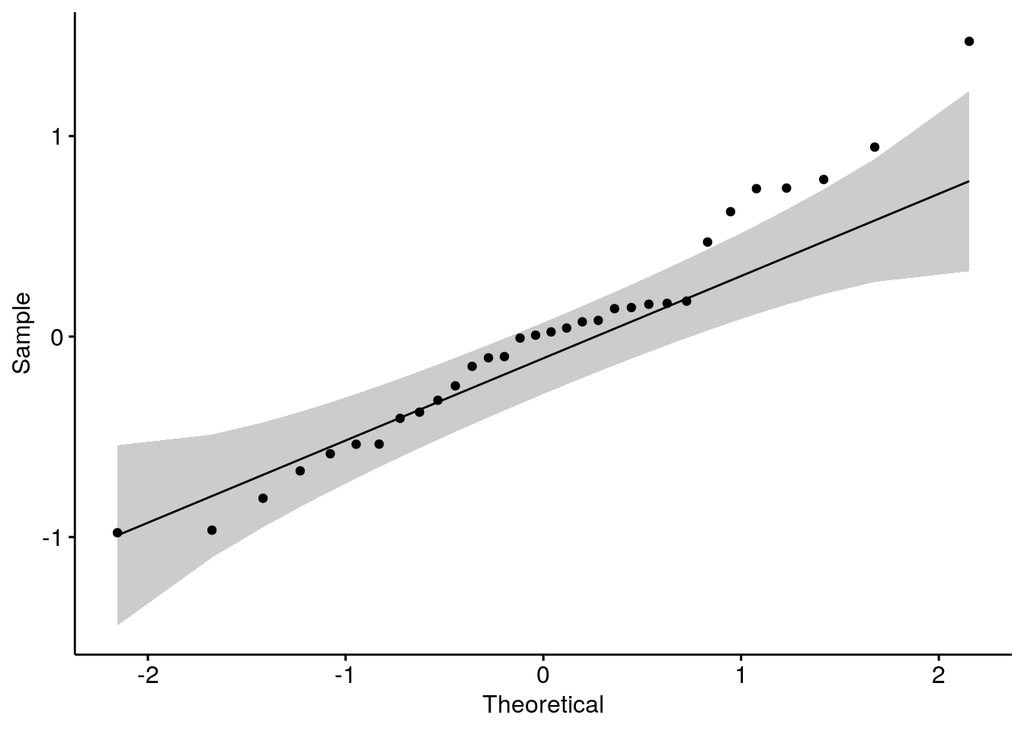

```r
ggqqplot(residuals(mod))
```

### Contrasting between Condition

In order to contrast the differences between conditions, we will perform a Dunnett’s Test (via the trt.vs.ctrl command) where we specify NC as the control group. We can also perform a Tukey’s test, where we do pairwise comparisons across all combinations (less power since we are performing more tests)

```r
##Now the contrasts, LNA-effect within a target (made possible by | command)
emmeans(mod, trt.vs.ctrl ~ LNA | Target.tar, ref="NC")
```

```
## $emmeans
## Target.tar = miR129:
##  LNA    emmean    SE df lower.CL upper.CL
##  LNA129 -8.401 0.309 26   -9.037   -7.766
##  LNA218 -5.693 0.309 26   -6.329   -5.058
##  NC     -6.461 0.219 26   -6.910   -6.012
##
## Target.tar = miR218:
##  LNA    emmean    SE df lower.CL upper.CL
##  LNA129 -0.414 0.309 26   -1.049    0.222
##  LNA218 -1.601 0.309 26   -2.236   -0.965
##  NC     -0.218 0.219 26   -0.668    0.231
##
## Confidence level used: 0.95
##
## $contrasts
## Target.tar = miR129:
##  contrast    estimate    SE df t.ratio p.value
##  LNA129 - NC   -1.940 0.379 26  -5.125  <.0001
##  LNA218 - NC    0.768 0.379 26   2.027  0.0978
##
## Target.tar = miR218:
##  contrast    estimate    SE df t.ratio p.value
##  LNA129 - NC   -0.195 0.379 26  -0.516  0.8155
##  LNA218 - NC   -1.383 0.379 26  -3.652  0.0023
##
## P value adjustment: dunnettx method for 2 tests
```

```r
## Or Tukeys pairwise comparison test

emmeans(mod, pairwise ~ LNA | Target.tar)
```

```
## $emmeans
## Target.tar = miR129:
##  LNA    emmean    SE df lower.CL upper.CL
##  LNA129 -8.401 0.309 26   -9.037   -7.766
##  LNA218 -5.693 0.309 26   -6.329   -5.058
##  NC     -6.461 0.219 26   -6.910   -6.012
##
## Target.tar = miR218:
##  LNA    emmean    SE df lower.CL upper.CL
##  LNA129 -0.414 0.309 26   -1.049    0.222
##  LNA218 -1.601 0.309 26   -2.236   -0.965
##  NC     -0.218 0.219 26   -0.668    0.231
##
## Confidence level used: 0.95
##
## $contrasts
## Target.tar = miR129:
##  contrast        estimate    SE df t.ratio p.value
##  LNA129 - LNA218   -2.708 0.437 26  -6.194  <.0001
##  LNA129 - NC       -1.940 0.379 26  -5.125  0.0001
##  LNA218 - NC        0.768 0.379 26   2.027  0.1256
##
## Target.tar = miR218:
##  contrast        estimate    SE df t.ratio p.value
##  LNA129 - LNA218    1.187 0.437 26   2.716  0.0302
##  LNA129 - NC       -0.195 0.379 26  -0.516  0.8642
##  LNA218 - NC       -1.383 0.379 26  -3.652  0.0032
##
## P value adjustment: tukey method for comparing a family of 3 estimates
```

## Repeated Measure ANOVA

All we need to do to perform a repeated measure ANOVA is add the term Error(Sample) where sample is the ID for the mice. The function residual does not work here and we need to extract them manually as seen below:

Do you note a difference in the results?

```r
## The Error(Sample)-term denotes the within subject dependence and this is how you would implement a repeated measure ANOVA
mod <- aov(-dCq ~ LNA*Target.tar + Error(Sample), data)
summary(mod)
```

```
##
## Error: Sample
##           Df Sum Sq Mean Sq F value Pr(>F)
## LNA        1  1.557  1.5566   5.708 0.0541 .
## Residuals  6  1.636  0.2727
## ---
## Signif. codes:  0 '***' 0.001 '**' 0.01 '*' 0.05 '.' 0.1 ' ' 1
##
## Error: Within
##                Df Sum Sq Mean Sq F value   Pr(>F)
## LNA             2   4.60    2.30    5.30   0.0148 *
## Target.tar      1 301.75  301.75  695.44  < 2e-16 ***
## LNA:Target.tar  2  15.26    7.63   17.58 4.77e-05 ***
## Residuals      19   8.24    0.43
## ---
## Signif. codes:  0 '***' 0.001 '**' 0.01 '*' 0.05 '.' 0.1 ' ' 1
```

```r
#lets test the normality of the residuals of our model
res <- proj(mod)
res <- res[[3]][, "Residuals"]
shapiro.test(res)
```

```
##
##  Shapiro-Wilk normality test
##
## data:  res
## W = 0.9684, p-value = 0.4563
```

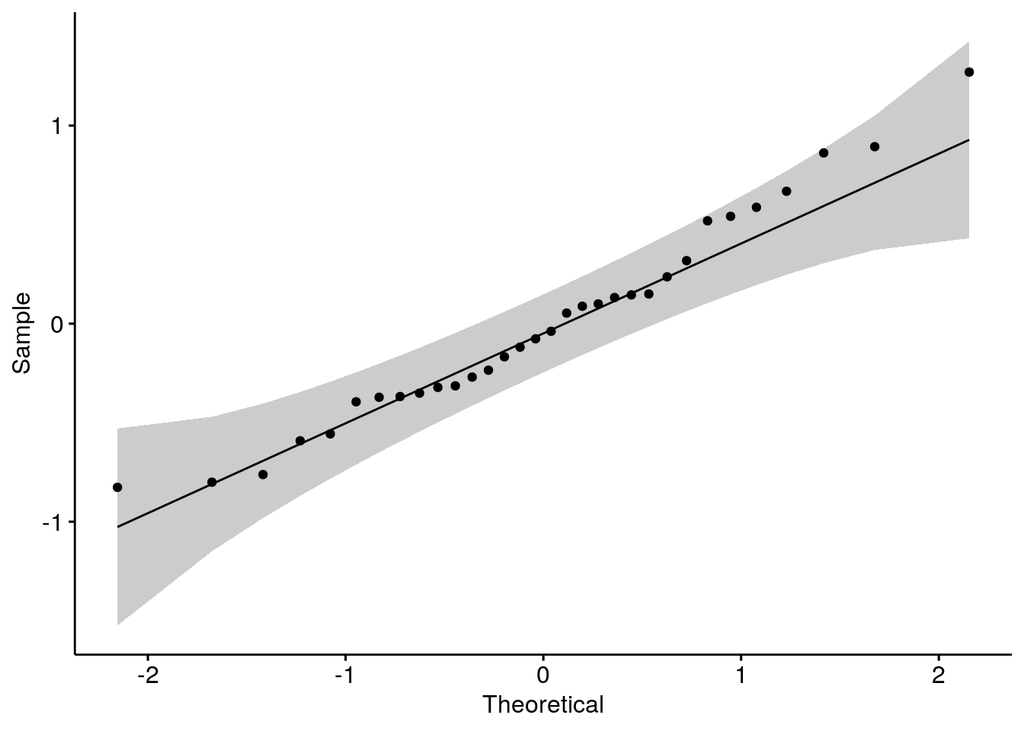

```r
ggqqplot(res)
```

### Same principle for the contrasts

```r
##Now the contrasts, LNA-effect within a target (made possible by | command)
emmeans(mod, trt.vs.ctrl ~ LNA | Target.tar, ref="NC")
```

```
## Note: re-fitting model with sum-to-zero contrasts
```

```
## NOTE: Results are based on intra-block estimates and are biased.
```

```
## $emmeans
## Target.tar = miR129:
##  LNA    emmean    SE   df lower.CL upper.CL
##  LNA129 -8.226 0.351 21.6   -8.954   -7.498
##  LNA218 -5.640 0.351 21.6   -6.368   -4.911
##  NC     -6.346 0.244 23.8   -6.851   -5.842
##
## Target.tar = miR218:
##  LNA    emmean    SE   df lower.CL upper.CL
##  LNA129 -0.238 0.351 21.6   -0.966    0.490
##  LNA218 -1.547 0.351 21.6   -2.275   -0.819
##  NC     -0.104 0.244 23.8   -0.608    0.401
##
## Warning: EMMs are biased unless design is perfectly balanced
## Confidence level used: 0.95
##
## $contrasts
## Target.tar = miR129:
##  contrast    estimate    SE df t.ratio p.value
##  LNA129 - NC   -1.880 0.436 19  -4.314  0.0007
##  LNA218 - NC    0.707 0.436 19   1.622  0.2139
##
## Target.tar = miR218:
##  contrast    estimate    SE df t.ratio p.value
##  LNA129 - NC   -0.134 0.436 19  -0.309  0.9209
##  LNA218 - NC   -1.444 0.436 19  -3.313  0.0071
##
## P value adjustment: dunnettx method for 2 tests
```

```r
## Or Tukeys pairwise comparison test

emmeans(mod, pairwise ~ LNA | Target.tar)
```

```
## Note: re-fitting model with sum-to-zero contrasts
## NOTE: Results are based on intra-block estimates and are biased.
```

```
## $emmeans
## Target.tar = miR129:
##  LNA    emmean    SE   df lower.CL upper.CL
##  LNA129 -8.226 0.351 21.6   -8.954   -7.498
##  LNA218 -5.640 0.351 21.6   -6.368   -4.911
##  NC     -6.346 0.244 23.8   -6.851   -5.842
##
## Target.tar = miR218:
##  LNA    emmean    SE   df lower.CL upper.CL
##  LNA129 -0.238 0.351 21.6   -0.966    0.490
##  LNA218 -1.547 0.351 21.6   -2.275   -0.819
##  NC     -0.104 0.244 23.8   -0.608    0.401
##
## Warning: EMMs are biased unless design is perfectly balanced
## Confidence level used: 0.95
##
## $contrasts
## Target.tar = miR129:
##  contrast        estimate    SE df t.ratio p.value
##  LNA129 - LNA218   -2.586 0.570 19  -4.534  0.0006
##  LNA129 - NC       -1.880 0.436 19  -4.314  0.0010
##  LNA218 - NC        0.707 0.436 19   1.622  0.2609
##
## Target.tar = miR218:
##  contrast        estimate    SE df t.ratio p.value
##  LNA129 - LNA218    1.309 0.570 19   2.295  0.0810
##  LNA129 - NC       -0.134 0.436 19  -0.309  0.9490
##  LNA218 - NC       -1.444 0.436 19  -3.313  0.0098
##
## P value adjustment: tukey method for comparing a family of 3 estimates
```

## Linear Mixed Model

We will have a separate seminar on linear mixed models and nesting structures later. This is just a short introduction to show you how it is done and how easy it is to implement in R. The random-effect term is determined by the (1|Sample)- term inside the lmer-function

```r
mod <- lmer(-dCq ~ LNA*Target.tar +  (1|Sample), data)
```

```
## boundary (singular) fit: see ?isSingular
```

```r
summary(mod)
```

```
## Linear mixed model fit by REML. t-tests use Satterthwaite's method [
## lmerModLmerTest]
## Formula: -dCq ~ LNA * Target.tar + (1 | Sample)
##    Data: data
##
## REML criterion at convergence: 58.5
##
## Scaled residuals:
##      Min       1Q   Median       3Q      Max
## -1.58250 -0.62236  0.02442  0.27255  2.38184
##
## Random effects:
##  Groups   Name        Variance  Std.Dev.
##  Sample   (Intercept) 2.626e-22 1.620e-11
##  Residual             3.823e-01 6.183e-01
## Number of obs: 32, groups:  Sample, 8
##
## Fixed effects:
##                            Estimate Std. Error      df t value Pr(>|t|)
## (Intercept)                 -8.4015     0.3091 26.0000 -27.176  < 2e-16 ***
## LNALNA218                    2.7081     0.4372 26.0000   6.194 1.49e-06 ***
## LNANC                        1.9405     0.3786 26.0000   5.125 2.42e-05 ***
## Target.tarmiR218             7.9879     0.4372 26.0000  18.271 2.35e-16 ***
## LNALNA218:Target.tarmiR218  -3.8953     0.6183 26.0000  -6.300 1.14e-06 ***
## LNANC:Target.tarmiR218      -1.7451     0.5355 26.0000  -3.259  0.00311 **
## ---
## Signif. codes:  0 '***' 0.001 '**' 0.01 '*' 0.05 '.' 0.1 ' ' 1
##
## Correlation of Fixed Effects:
##             (Intr) LNALNA218 LNANC  T.R218 LNALNA218:
## LNALNA218   -0.707
## LNANC       -0.816  0.577
## Trgt.trR218 -0.707  0.500     0.577
## LNALNA218:T  0.500 -0.707    -0.408 -0.707
## LNANC:T.R21  0.577 -0.408    -0.707 -0.816  0.577
## optimizer (nloptwrap) convergence code: 0 (OK)
## boundary (singular) fit: see ?isSingular
```

```r
##Now the contrasts, LNA-effect within a target (made possible by | command)
emmeans(mod, trt.vs.ctrl ~ LNA | Target.tar, ref="NC")
```

```
## $emmeans
## Target.tar = miR129:
##  LNA    emmean    SE df lower.CL upper.CL
##  LNA129 -8.401 0.317 26   -9.054   -7.749
##  LNA218 -5.693 0.317 26   -6.346   -5.041
##  NC     -6.461 0.219 26   -6.910   -6.012
##
## Target.tar = miR218:
##  LNA    emmean    SE df lower.CL upper.CL
##  LNA129 -0.414 0.317 26   -1.066    0.239
##  LNA218 -1.601 0.317 26   -2.253   -0.948
##  NC     -0.218 0.219 26   -0.668    0.231
##
## Degrees-of-freedom method: kenward-roger
## Confidence level used: 0.95
##
## $contrasts
## Target.tar = miR129:
##  contrast    estimate    SE   df t.ratio p.value
##  LNA129 - NC   -1.940 0.385 22.5  -5.035  0.0001
##  LNA218 - NC    0.768 0.385 22.5   1.992  0.1078
##
## Target.tar = miR218:
##  contrast    estimate    SE   df t.ratio p.value
##  LNA129 - NC   -0.195 0.385 22.5  -0.507  0.8210
##  LNA218 - NC   -1.383 0.385 22.5  -3.588  0.0031
##
## Degrees-of-freedom method: kenward-roger
## P value adjustment: dunnettx method for 2 tests
```

```r
## Or Tukeys pairwise comparison test

emmeans(mod, pairwise ~ LNA | Target.tar)
```

```
## $emmeans
## Target.tar = miR129:
##  LNA    emmean    SE df lower.CL upper.CL
##  LNA129 -8.401 0.317 26   -9.054   -7.749
##  LNA218 -5.693 0.317 26   -6.346   -5.041
##  NC     -6.461 0.219 26   -6.910   -6.012
##
## Target.tar = miR218:
##  LNA    emmean    SE df lower.CL upper.CL
##  LNA129 -0.414 0.317 26   -1.066    0.239
##  LNA218 -1.601 0.317 26   -2.253   -0.948
##  NC     -0.218 0.219 26   -0.668    0.231
##
## Degrees-of-freedom method: kenward-roger
## Confidence level used: 0.95
##
## $contrasts
## Target.tar = miR129:
##  contrast        estimate    SE   df t.ratio p.value
##  LNA129 - LNA218   -2.708 0.460 26.0  -5.884  <.0001
##  LNA129 - NC       -1.940 0.385 22.5  -5.035  0.0001
##  LNA218 - NC        0.768 0.385 22.5   1.992  0.1373
##
## Target.tar = miR218:
##  contrast        estimate    SE   df t.ratio p.value
##  LNA129 - LNA218    1.187 0.460 26.0   2.580  0.0407
##  LNA129 - NC       -0.195 0.385 22.5  -0.507  0.8687
##  LNA218 - NC       -1.383 0.385 22.5  -3.588  0.0044
##
## Degrees-of-freedom method: kenward-roger
## P value adjustment: tukey method for comparing a family of 3 estimates
```

## Perform Paired T-Tests

What if we want to perform paired t-tests instead of ANOVAs? That’s how you would do it. Of course, we need to correct for multiple testing:

```r
data$dCq <- -1*data$dCq
t.tests <- data %>%
  ## We group here according to miRNA-levels and Coort
  group_by(Target.tar, Coort) %>%
  ## We perform the t-test here, where paired is set as TRUE
    t_test(dCq ~ LNA, paired = T)

## Add multiple testing correction, there are many. You can check a few, but the results are all similar -> no comparison passes the multiple correction
t.tests$p.adj <-  p.adjust(t.tests$p, method="fdr")


t.tests <- add_significance(t.tests, p.col="p.adj")

t.tests
```

```
## # A tibble: 4 × 12
##   Target.tar Coort   .y.   group1 group2    n1    n2 statistic    df     p p.adj
##   <chr>      <chr>   <chr> <chr>  <chr>  <int> <int>     <dbl> <dbl> <dbl> <dbl>
## 1 miR129     Coort1… dCq   LNA218 NC         4     4     0.593     3 0.595 0.595
## 2 miR129     Coort2… dCq   LNA129 NC         4     4    -4.79      3 0.017 0.068
## 3 miR218     Coort1… dCq   LNA218 NC         4     4    -3.32      3 0.045 0.09
## 4 miR218     Coort2… dCq   LNA129 NC         4     4    -1.04      3 0.376 0.501
## # … with 1 more variable: p.adj.signif <chr>
```

### Exercise

Perform an unpaired t-test -> does the data change? And why?

## Classical ddCq Approach

What if we want to perform a classical ddCQ analysis. Again, a ddCq is nothing else than a division in the log-transform scale, meaning we need to subtract a condition by a control. In our case, we first normalized to a house-keeping gene and now we add a second layer of normalization, which is the LNA-effect vs negative control. Again, we can split the data into two and then re-merge them:

```r
## %in% is used if we have a condition with more than one matching condition (instead of concatenating twice the same statement)
lna <- subset(data, LNA %in% c("LNA218", "LNA129"))
ctrl <- subset(data, LNA == "NC")

## We will merge the two tables according to mouse and coort, which will make sure that we are pairing the right negative controls with the right condition

ddCq.data <- merge(lna, ctrl, suffixes = c(".lna", ".ctrl"), by=c("Sample", "Coort", "Target.tar"))

head(ddCq.data)
```

```
##   Sample           Coort Target.tar Biological Set Name.lna Rep1.tar.lna
## 1    M33 Coort1 (LNA218)     miR129                      RH     27.14422
## 2    M33 Coort1 (LNA218)     miR218                      RH     22.64389
## 3    M34 Coort1 (LNA218)     miR129                      RH     26.65820
## 4    M34 Coort1 (LNA218)     miR218                      RH     22.39795
## 5    M35 Coort1 (LNA218)     miR129                      LH     27.17036
## 6    M35 Coort1 (LNA218)     miR218                      LH     22.02021
##   Rep2.tar.lna Rep3.tar.lna Rep4.tar.lna Rep5.tar.lna Rep6.tar.lna
## 1     27.27965     27.50592           NA           NA           NA
## 2     22.96904     22.85769           NA           NA           NA
## 3     27.02554     26.85463           NA           NA           NA
## 4     22.50246     22.55252           NA           NA           NA
## 5     27.19724     27.26765           NA           NA           NA
## 6     22.15723     22.30565           NA           NA           NA
##   meanCq.tar.lna Target.u6.lna Rep1.u6.lna Rep2.u6.lna Rep3.u6.lna Rep4.u6.lna
```

[output cut: 41 more lines]

```r
## Now we have a rather wide data.frame. At this point we could also clip the data a bit and omit useless columns. Or we keep just going. We just need to add a normalized ddCq column

ddCq.data$ddCq <- ddCq.data$dCq.lna - ddCq.data$dCq.ctrl
ddCq.data$fold.ddCq <- 2^- ddCq.data$ddCq
```

## Lets Plot the ddCq

We will add a dashed line at the intercept for 0, indicating no change (log(0) = 1 because x^0 = 1)

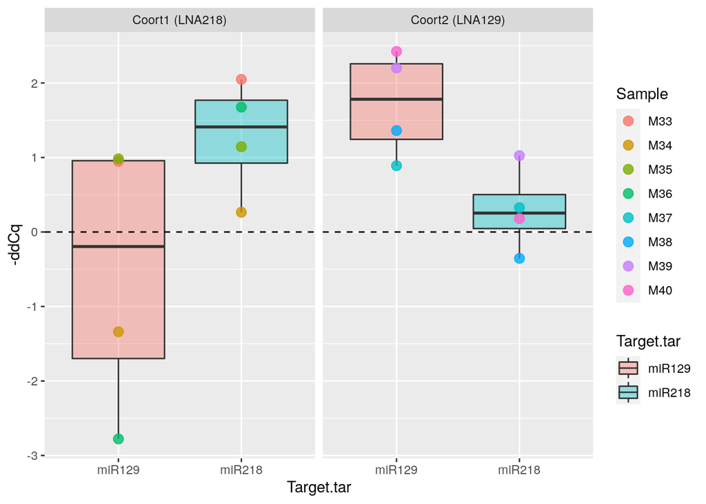

```r
p <- ggplot(ddCq.data, aes(x=Target.tar, y=-ddCq, group= Target.tar))  +
geom_boxplot(alpha=0.4, aes(fill=Target.tar))+

  geom_point(aes(color=Sample), alpha=0.8, position = position_dodge(0.75), size=3) + facet_grid(.~Coort, scales="free")




p+ geom_hline(yintercept = 0, linetype="dashed")
```

### Exercise

Create a plot with the fold-changes in the y-axis. Change also the intercept to an appropriate number.

## Statistics

```r
mod <- aov(-ddCq ~ Coort*Target.tar + Error(Sample), ddCq.data)

summary(mod)
```

```
##
## Error: Sample
##           Df Sum Sq Mean Sq F value Pr(>F)
## Coort      1  1.631   1.631    1.14  0.327
## Residuals  6  8.583   1.430
##
## Error: Within
##                  Df Sum Sq Mean Sq F value Pr(>F)
## Target.tar        1  0.164   0.164   0.167 0.6971
## Coort:Target.tar  1 10.591  10.591  10.763 0.0168 *
## Residuals         6  5.904   0.984
## ---
## Signif. codes:  0 '***' 0.001 '**' 0.01 '*' 0.05 '.' 0.1 ' ' 1
```

```r
emmeans(mod, pairwise ~ Target.tar | Coort)
```

```
## Note: re-fitting model with sum-to-zero contrasts
```

```
## $emmeans
## Coort = Coort1 (LNA218):
##  Target.tar emmean    SE   df lower.CL upper.CL
##  miR129     -0.546 0.549 11.6  -1.7480    0.655
##  miR218      1.283 0.549 11.6   0.0818    2.485
##
## Coort = Coort2 (LNA129):
##  Target.tar emmean    SE   df lower.CL upper.CL
##  miR129      1.719 0.549 11.6   0.5178    2.921
##  miR218      0.295 0.549 11.6  -0.9068    1.496
##
## Warning: EMMs are biased unless design is perfectly balanced
## Confidence level used: 0.95
##
## $contrasts
## Coort = Coort1 (LNA218):
##  contrast        estimate    SE df t.ratio p.value
##  miR129 - miR218    -1.83 0.701  6  -2.609  0.0402
##
## Coort = Coort2 (LNA129):
##  contrast        estimate    SE df t.ratio p.value
##  miR129 - miR218     1.42 0.701  6   2.031  0.0885
```

```r
## Does it make sense to compare miR129 to miR218? not really, but depending on your experimental setup, this could make sense.
```

## One Sample T-test

We could also perform a one sample t-tests per condition checking whether the effect of introducing an LNA elicited a change. The mu will be 0, since our null-hypothesis is no change hence 0.

What should mu be if we dont perform the t-test in the log2-scale?

```r
##One sample T-test


ddCq.data$ddCq <- -1 * ddCq.data$ddCq


one.sample.TTest <- ddCq.data %>%
                  group_by(Coort, Target.tar) %>%
                      ##Here we define mu = 0
                            t_test(ddCq ~ 1, mu=0)

## we need to adjust the p-values for multiple testing
one.sample.TTest$p.adjusted <- p.adjust(one.sample.TTest$p, method = "fdr")

one.sample.TTest <- add_significance(one.sample.TTest, p.col="p.adjusted")

one.sample.TTest
```

```
## # A tibble: 4 × 11
##   Coort   Target.tar .y.   group1 group2     n statistic    df      p p.adjusted
##   <chr>   <chr>      <chr> <chr>  <chr>  <int>     <dbl> <dbl>  <dbl>      <dbl>
## 1 Coort1… miR129     ddCq  1      null …     4    -0.593     3 0.595      0.595
## 2 Coort1… miR218     ddCq  1      null …     4     3.32      3 0.0451     0.0902
## 3 Coort2… miR129     ddCq  1      null …     4     4.79      3 0.0173     0.0692
## 4 Coort2… miR218     ddCq  1      null …     4     1.04      3 0.376      0.501
## # … with 1 more variable: p.adjusted.signif <chr>
```

Did you notice how these results are EXACTLY the same as the paired two-sample t-test we performed earlier? Why do you think?

## Exercise for you

Try to write a r-markdown script with one of your qPCR-datasets and analyze it using this tutorial as a template. You can send it to me for corrections and suggestions